# DATA 698: Masters Research Project

Gabriella Martinez & Gabriel Campos

Last edited December 02, 2024

# Packages

```r
#load libraries
library(tidyverse)
library(tidycensus)
library(rvest)
library(ggplot2)
library(reshape2)
library(corrplot)
library(car)
library(Hmisc)
library(randomForest)
library(caret)
library(janitor)
```

```r
# Define the path to the Key folder
key_file_path <- file.path(".", "Key", "api_key.txt")

# Read the API key from the file
api_key <- readLines(key_file_path, warn = FALSE)

# Print the API key (for debugging purposes; avoid doing this in production)
#cat("API Key:", api_key, "\n")
```

# Load Data

## Election Data

```r
#https://dataverse.harvard.edu/dataset.xhtml?persistentId=doi:10.7910/DVN/VOQCHQ
elections <- read_csv("https://raw.githubusercontent.com/gabbypaola/DATA698/refs/heads/main/data/countypres_2000-2020.csv")
#glimpse(elections)
```

### Cleaning Election data

```r
#identify empty and NA values. 57 NA values in the county_fips column
colSums(elections == "" | is.na(elections))
```

```
##           year          state       state_po    county_name    county_fips
##              0              0              0              0             57
##         office      candidate          party candidatevotes     totalvotes
##              0              0              0              0              0
##        version           mode
##              0              0
```

```r
elections %>%
  filter(is.na(county_fips))
```

```
## # A tibble: 57 × 12
##     year state        state_po county_name    county_fips office candidate party
##    <dbl> <chr>        <chr>    <chr>          <chr>       <chr>  <chr>     <chr>
##  1  2000 CONNECTICUT  CT       STATEWIDE WRI… <NA>        US PR… AL GORE   DEMO…
##  2  2000 MAINE        ME       MAINE UOCAVA   <NA>        US PR… AL GORE   DEMO…
##  3  2000 RHODE ISLAND RI       FEDERAL PRECI… <NA>        US PR… AL GORE   DEMO…
##  4  2000 CONNECTICUT  CT       STATEWIDE WRI… <NA>        US PR… GEORGE W… REPU…
##  5  2000 MAINE        ME       MAINE UOCAVA   <NA>        US PR… GEORGE W… REPU…
##  6  2000 RHODE ISLAND RI       FEDERAL PRECI… <NA>        US PR… GEORGE W… REPU…
##  7  2000 CONNECTICUT  CT       STATEWIDE WRI… <NA>        US PR… RALPH NA… GREEN
##  8  2000 MAINE        ME       MAINE UOCAVA   <NA>        US PR… RALPH NA… GREEN
##  9  2000 RHODE ISLAND RI       FEDERAL PRECI… <NA>        US PR… RALPH NA… GREEN
## 10  2000 CONNECTICUT  CT       STATEWIDE WRI… <NA>        US PR… OTHER     OTHER
## # ℹ 47 more rows
## # ℹ 4 more variables: candidatevotes <dbl>, totalvotes <dbl>, version <dbl>,
## #   mode <chr>
```

```r
elections %>%
  filter(state_po=="DC")
```

```
## # A tibble: 21 × 12
##     year state           state_po county_name county_fips office candidate party
##    <dbl> <chr>           <chr>    <chr>       <chr>       <chr>  <chr>     <chr>
##  1  2000 DISTRICT OF CO… DC       DISTRICT O… 11001       US PR… AL GORE   DEMO…
##  2  2000 DISTRICT OF CO… DC       DISTRICT O… 11001       US PR… GEORGE W… REPU…
##  3  2000 DISTRICT OF CO… DC       DISTRICT O… 11001       US PR… RALPH NA… GREEN
##  4  2000 DISTRICT OF CO… DC       DISTRICT O… 11001       US PR… OTHER     OTHER
##  5  2004 DISTRICT OF CO… DC       DISTRICT O… 11001       US PR… JOHN KER… DEMO…
##  6  2004 DISTRICT OF CO… DC       DISTRICT O… 11001       US PR… GEORGE W… REPU…
##  7  2004 DISTRICT OF CO… DC       DISTRICT O… 11001       US PR… OTHER     OTHER
##  8  2008 DISTRICT OF CO… DC       DISTRICT O… 11001       US PR… BARACK O… DEMO…
##  9  2008 DISTRICT OF CO… DC       DISTRICT O… 11001       US PR… JOHN MCC… REPU…
## 10  2008 DISTRICT OF CO… DC       DISTRICT O… 11001       US PR… OTHER     OTHER
## # ℹ 11 more rows
## # ℹ 4 more variables: candidatevotes <dbl>, totalvotes <dbl>, version <dbl>,
## #   mode <chr>
```

```r
#clean elections data
elections_data <- elections %>%
  #new name = old name
  rename(state_abbr = state_po, pol_identity = party, FIPS = county_fips) %>%
  mutate(FIPS = ifelse(state_abbr == "DC", "11001", FIPS))

#there are 52 NAs remaining
remaining_nas <- elections_data %>%
  filter(is.na(FIPS))

#what are the NAs?
#ME MAINE UOCAVA= Uniformed Service & Overseas (UOCAVA) Voters- https://www.maine.gov/sos/cec/elec/voter-info/uocava.html
#CT= STATEWIDE WRITEIN ~ You may decide to write in the name of a candidate who is not listed on your ballot- https://www.usa.gov/write-in-candidates
#RI Federal Precinct- no info found
remaining_nas %>%
  count(state_abbr, county_name)
```

```
## # A tibble: 3 × 3
##   state_abbr county_name           n
##   <chr>      <chr>             <int>
## 1 CT         STATEWIDE WRITEIN    16
## 2 ME         MAINE UOCAVA         16
## 3 RI         FEDERAL PRECINCT     20
```

The remaining NA values in the FIPS column are votes assigned at a state-wide level, not to any count. The “MAINE UOCAVA” county record for the state of Maine represents the count of votes from Uniformed Service & Overseas (UOCAVA) Voters. The “STATEWIDE WRITEIN” for Connecticut represents the count of votes for self-selected candidates not on the presidential ballot. It is unclear what the “FEDERAL PRECINCT” for the state of Rhode Island exactly represents. Either way, our analysis will be conducted at the county level, so these records cannot be used.

Next we will assess the effect that removing these votes will have on our overall analysis.

```r
#nas
nrow(remaining_nas)
```

```
## [1] 52
```

```r
# Determine the total number of records in the table.
nrow(elections_data)
```

```
## [1] 72617
```

```r
round(nrow(remaining_nas)/nrow(elections_data)*100,3)
```

```
## [1] 0.072
```

```r
# Determine the total number of votes cast across all counties in all elections.
votecount <- elections_data %>%
  summarise(count= sum(candidatevotes))

votecount
```

```
## # A tibble: 1 × 1
##       count
##       <dbl>
## 1 782944050
```

```r
# Determine how many votes are associated with state-level counts
null_fips_votecount <- remaining_nas %>%
  summarise(count=sum(candidatevotes))

null_fips_votecount
```

```
## # A tibble: 1 × 1
##   count
##   <dbl>
## 1 13009
```

```r
round((null_fips_votecount$count/votecount$count)*100,3)
```

```
## [1] 0.002
```

There were 52 records with state-level counts and null FIPS values in the data, representing 13009 votes. This amounts to 0.072% of the total records and 0.002% of the total votes.

The records with state-level counts and null FIPS values represent a small percentage of the total, and they are unlikely to change the overall analysis. Given our assessment, the records will be removed.

```r
#transform data- drop NAs, keep dem and gop only, group records for each candidate by county and year
candidate_votes <- elections_data %>%
  filter(!is.na(FIPS), pol_identity %in% c('DEMOCRAT', 'REPUBLICAN')) %>%
  group_by(FIPS,county_name, state, candidate, year, pol_identity, totalvotes) %>%
  summarise(candidate_votes = sum(candidatevotes)) %>%
  ungroup() %>%
  arrange(FIPS, year)
```

[output not shown]

```r
#spread the candidate votes values
elections_pivot_df <- candidate_votes %>%
   pivot_wider(id_cols = c(year, FIPS, county_name, state, totalvotes),
               names_from = pol_identity,
               values_from = candidate_votes) %>%
  rename(votes_dem = DEMOCRAT,  votes_gop = REPUBLICAN
         #votes_other = OTHER,votes_grn = GREEN, votes_lib = LIBERTARIAN
         )
```

## Census Bureau data

About Census Bureau American Community Survey (ACS) data https://www.census.gov/programs-surveys/acs/guidance/estimates.html

### Citizen Voting Age Population

Citizen Voting Age Population, Census Bureau population estimates generated using the American Community Survey

```r
#CVAP- Citizen Voting Age Population, Census Bureau population estimates generated using the American Community Survey

#https://www.census.gov/programs-surveys/decennial-census/about/voting-rights/cvap.2010.html#list-tab-1518558936 (2008)
cvap2008 <- read_csv("https://raw.githubusercontent.com/GitableGabe/DATA_698/refs/heads/main/data/CountyCVAP_2006-2010.csv?token=GHSAT0AAAAAACXYKDAYQCHUVJY2V6BVWU7SZXPAZJQ") %>%
  rename_with(tolower) %>%
  mutate(year=2008)

#https://www.census.gov/programs-surveys/decennial-census/about/voting-rights/cvap.2014.html#list-tab-1518558936 (2012)
cvap2012 <- read_csv("https://raw.githubusercontent.com/GitableGabe/DATA_698/refs/heads/main/data/CountyCVAP_2010-2014.csv?token=GHSAT0AAAAAACXYKDAYHOL27SGWSEL2AS6IZXPAYSQ") %>%
  rename_with(tolower) %>%
  mutate(year=2012)

#https://www.census.gov/programs-surveys/decennial-census/about/voting-rights/cvap/2014-2018-CVAP.html (2016)
cvap2016 <- read_csv("https://raw.githubusercontent.com/GitableGabe/DATA_698/refs/heads/main/data/CountyCVAP_2014-2018.csv?token=GHSAT0AAAAAACXYKDAZJU7ABMJMRNP5WOSIZXPATUQ") %>%
  mutate(year=2016)

#https://www.census.gov/programs-surveys/decennial-census/about/voting-rights/cvap/2017-2021-CVAP.html (2020)
cvap2020 <- read_csv("https://raw.githubusercontent.com/GitableGabe/DATA_698/refs/heads/main/data/CountyCVAP_2017-2021.csv?token=GHSAT0AAAAAACXYKDAYJWVR6SZPSH4NRMSSZXPASSQ") %>%
  mutate(year=2020)

cvap_df <- rbind(cvap2008, cvap2012, cvap2016, cvap2020) %>%
  filter(lntitle == 'Total', !str_detect(geoname, "Puerto Rico")) %>%
  mutate(FIPS = str_sub(geoid, -5)) %>%
  select(c('year', 'FIPS', 'geoname', 'cvap_est'))

#identify empty and NA values
colSums(cvap_df == "" | is.na(cvap_df))
```

[output not shown]

#### Merge with Election data

```r
voting_info_df <- left_join(elections_pivot_df, cvap_df, by = c("FIPS", "year"))

voting_info_df
```

```
## # A tibble: 18,928 × 9
##     year FIPS  county_name state totalvotes votes_dem votes_gop geoname cvap_est
##    <dbl> <chr> <chr>       <chr>      <dbl>     <dbl>     <dbl> <chr>      <dbl>
##  1  2000 01001 AUTAUGA     ALAB…      17208      4942     11993 <NA>          NA
##  2  2004 01001 AUTAUGA     ALAB…      20081      4758     15196 <NA>          NA
##  3  2008 01001 AUTAUGA     ALAB…      23641      6093     17403 Autaug…    38010
##  4  2012 01001 AUTAUGA     ALAB…      23932      6363     17379 Autaug…    40545
##  5  2016 01001 AUTAUGA     ALAB…      24973      5936     18172 Autaug…    41305
##  6  2020 01001 AUTAUGA     ALAB…      27770      7503     19838 Autaug…    43905
##  7  2000 01003 BALDWIN     ALAB…      56480     13997     40872 <NA>          NA
##  8  2004 01003 BALDWIN     ALAB…      69320     15599     52971 <NA>          NA
##  9  2008 01003 BALDWIN     ALAB…      81413     19386     61271 Baldwi…   130865
## 10  2012 01003 BALDWIN     ALAB…      85338     18424     66016 Baldwi…   144120
## # ℹ 18,918 more rows
```

```r
#identify empty and NA values
colSums(voting_info_df == "" | is.na(voting_info_df))
```

```
##        year        FIPS county_name       state  totalvotes   votes_dem
##           0           0           0           0           0           0
##   votes_gop     geoname    cvap_est
##           0        6467        6467
```

```r
voting_info_df_NAs <- voting_info_df %>%
  filter(is.na(geoname), is.na(cvap_est))

voting_info_df_NAs
```

```
## # A tibble: 6,467 × 9
##     year FIPS  county_name state totalvotes votes_dem votes_gop geoname cvap_est
##    <dbl> <chr> <chr>       <chr>      <dbl>     <dbl>     <dbl> <chr>      <dbl>
##  1  2000 01001 AUTAUGA     ALAB…      17208      4942     11993 <NA>          NA
##  2  2004 01001 AUTAUGA     ALAB…      20081      4758     15196 <NA>          NA
##  3  2000 01003 BALDWIN     ALAB…      56480     13997     40872 <NA>          NA
##  4  2004 01003 BALDWIN     ALAB…      69320     15599     52971 <NA>          NA
##  5  2000 01005 BARBOUR     ALAB…      10395      5188      5096 <NA>          NA
##  6  2004 01005 BARBOUR     ALAB…      10777      4832      5899 <NA>          NA
##  7  2000 01007 BIBB        ALAB…       7101      2710      4273 <NA>          NA
##  8  2004 01007 BIBB        ALAB…       7600      2089      5472 <NA>          NA
##  9  2000 01009 BLOUNT      ALAB…      17973      4977     12667 <NA>          NA
## 10  2004 01009 BLOUNT      ALAB…      21504      3938     17386 <NA>          NA
## # ℹ 6,457 more rows
```

```r
unique(voting_info_df_NAs$year)
```

```
## [1] 2000 2004 2008 2012 2016 2020
```

```r
voting_info_df <- voting_info_df %>%
  filter(year >= 2008)

voting_info_df_NAs2 <- voting_info_df %>%
  filter(is.na(geoname), is.na(cvap_est))

voting_info_df_NAs2
```

```
## # A tibble: 158 × 9
##     year FIPS  county_name state totalvotes votes_dem votes_gop geoname cvap_est
##    <dbl> <chr> <chr>       <chr>      <dbl>     <dbl>     <dbl> <chr>      <dbl>
##  1  2008 02001 DISTRICT 1  ALAS…       6970      2597      4149 <NA>          NA
##  2  2012 02001 DISTRICT 1  ALAS…       7722      1518      5899 <NA>          NA
##  3  2016 02001 DISTRICT 1  ALAS…       6638      2573      3180 <NA>          NA
##  4  2020 02001 DISTRICT 1  ALAS…       7314      3477      3511 <NA>          NA
##  5  2008 02002 DISTRICT 2  ALAS…       7735      3468      4029 <NA>          NA
##  6  2012 02002 DISTRICT 2  ALAS…       9058      3096      5509 <NA>          NA
##  7  2016 02002 DISTRICT 2  ALAS…       5492      1585      3188 <NA>          NA
##  8  2020 02002 DISTRICT 2  ALAS…       6136      2104      3674 <NA>          NA
##  9  2008 02003 DISTRICT 3  ALAS…       8767      5657      2829 <NA>          NA
## 10  2012 02003 DISTRICT 3  ALAS…       6069      2034      3769 <NA>          NA
## # ℹ 148 more rows
```

```r
voting_info_df <- voting_info_df %>%
  filter(state != "ALASKA")

voting_info_df_NAs3 <- voting_info_df %>%
  filter(is.na(geoname), is.na(cvap_est))

voting_info_df_NAs3
```

```
## # A tibble: 6 × 9
##    year FIPS  county_name state  totalvotes votes_dem votes_gop geoname cvap_est
##   <dbl> <chr> <chr>       <chr>       <dbl>     <dbl>     <dbl> <chr>      <dbl>
## 1  2008 36000 KANSAS CITY MISSO…     153219    120102     31854 <NA>          NA
## 2  2012 36000 KANSAS CITY MISSO…     136802    105670     29509 <NA>          NA
## 3  2016 36000 KANSAS CITY MISSO…     128601     97735     24654 <NA>          NA
## 4  2020 36000 KANSAS CITY MISSO…     136645    107660     26393 <NA>          NA
## 5  2012 51515 BEDFORD     VIRGI…       2805      1225      1527 <NA>          NA
## 6  2016 51515 BEDFORD     VIRGI…          0         0         0 <NA>          NA
```

```r
voting_info_df_cleaning <- voting_info_df %>%
  filter(FIPS %in% c('29095', '36000', '51019', '51515')) %>%
  arrange(year, FIPS)

voting_info_df_cleaning
```

```
## # A tibble: 15 × 9
##     year FIPS  county_name state totalvotes votes_dem votes_gop geoname cvap_est
##    <dbl> <chr> <chr>       <chr>      <dbl>     <dbl>     <dbl> <chr>      <dbl>
##  1  2008 29095 JACKSON     MISS…     186047     90722     92833 Jackso…   481045
##  2  2008 36000 KANSAS CITY MISS…     153219    120102     31854 <NA>          NA
##  3  2008 51019 BEDFORD     VIRG…      35830     11017     24420 Bedfor…    51755
##  4  2008 51515 BEDFORD     VIRG…       2734      1208      1497 Bedfor…     4595
##  5  2012 29095 JACKSON     MISS…     174764     78283     93199 Jackso…   493440
##  6  2012 36000 KANSAS CITY MISS…     136802    105670     29509 <NA>          NA
##  7  2012 51019 BEDFORD     VIRG…      37425     10209     26679 Bedfor…    58850
##  8  2012 51515 BEDFORD     VIRG…       2805      1225      1527 <NA>          NA
##  9  2016 29095 JACKSON     MISS…     173275     71237     91557 Jackso…   506340
## 10  2016 36000 KANSAS CITY MISS…     128601     97735     24654 <NA>          NA
## 11  2016 51019 BEDFORD     VIRG…      42525      9768     30659 Bedfor…    61205
## 12  2016 51515 BEDFORD     VIRG…          0         0         0 <NA>          NA
## 13  2020 29095 JACKSON     MISS…     196418     92182    100142 Jackso…   523040
## 14  2020 36000 KANSAS CITY MISS…     136645    107660     26393 <NA>          NA
## 15  2020 51019 BEDFORD     VIRG…      48669     12176     35600 Bedfor…    62435
```

```r
voting_info_df_cleaning %>%
  count(FIPS, state, county_name, geoname) %>%
  filter(geoname %in% c("Jackson County, Missouri", "Bedford County, Virginia")) %>%
  select(-n)
```

```
## # A tibble: 2 × 4
##   FIPS  state    county_name geoname
##   <chr> <chr>    <chr>       <chr>
## 1 29095 MISSOURI JACKSON     Jackson County, Missouri
## 2 51019 VIRGINIA BEDFORD     Bedford County, Virginia
```

```r
# Define the counties to filter and group data by year and state
county_groups <- voting_info_df %>%
  filter(FIPS %in% c('29095', '36000', '51019', '51515')) %>%
  group_by(year, state) %>%
  summarise(    # Concatenate FIPS codes and county names
    FIPS = paste(unique(FIPS), collapse = ", "),
    county_name = paste(unique(county_name), collapse = ", "),
            across(where(is.numeric), sum, na.rm = TRUE)) %>%
  mutate(geoname = case_when(state == "MISSOURI" ~ "Jackson County, Missouri",
                             state == "VIRGINIA" ~ "Bedford County, Virginia"))
county_groups
```

```
## # A tibble: 8 × 9
## # Groups:   year [4]
##    year state  FIPS  county_name totalvotes votes_dem votes_gop cvap_est geoname
##   <dbl> <chr>  <chr> <chr>            <dbl>     <dbl>     <dbl>    <dbl> <chr>
## 1  2008 MISSO… 2909… JACKSON, K…     339266    210824    124687   481045 Jackso…
## 2  2008 VIRGI… 5101… BEDFORD          38564     12225     25917    56350 Bedfor…
## 3  2012 MISSO… 2909… JACKSON, K…     311566    183953    122708   493440 Jackso…
## 4  2012 VIRGI… 5101… BEDFORD          40230     11434     28206    58850 Bedfor…
## 5  2016 MISSO… 2909… JACKSON, K…     301876    168972    116211   506340 Jackso…
## 6  2016 VIRGI… 5101… BEDFORD          42525      9768     30659    61205 Bedfor…
## 7  2020 MISSO… 2909… JACKSON, K…     333063    199842    126535   523040 Jackso…
## 8  2020 VIRGI… 51019 BEDFORD          48669     12176     35600    62435 Bedfor…
```

#### Clean up

```r
#remove the previous observations
voting_info_df <- voting_info_df %>%
  filter(!FIPS %in% c('29095', '36000', '51019', '51515'))

#replace with the calculated observations
voting_info_df <- rbind(voting_info_df, county_groups)


FIPS <- unique(voting_info_df$FIPS)

length(FIPS)
```

```
## [1] 3114
```

```r
county_names <- voting_info_df %>%
  group_by(state, county_name) %>%
  mutate(county_name = str_to_title(county_name),
         state = str_to_title(state)) %>%
  summarise(n=n())
length(county_names)
```

```
## [1] 3
```

#### Popular Vote

```r
voting_info_df %>%
  group_by(year) %>%
  summarise(total_dem = sum(votes_dem),
            total_gop = sum(votes_gop)) %>%
  mutate(result = if_else(total_gop > total_dem, "Republican Party","Democratic Party"))
```

```
## # A tibble: 4 × 4
##    year total_dem total_gop result
##   <dbl>     <dbl>     <dbl> <chr>
## 1  2008  69324684  59734854 Democratic Party
## 2  2012  65628040  60500800 Democratic Party
## 3  2016  65724133  62814943 Democratic Party
## 4  2020  81109594  74028963 Democratic Party
```

#### Aggregate by State

```r
voting_info_df <- voting_info_df %>%
  group_by(state, year) %>%
  summarise(totalvotes = sum(totalvotes),
            votes_dem = sum(votes_dem),
            votes_gop = sum(votes_gop),
            cvap_est = sum(cvap_est)) %>%
  ungroup() %>%
  arrange(state, year)
#49 states + DC, Alaska has been removed
length(unique(voting_info_df$state))
```

```
## [1] 50
```

#### Calculate additional columns

```r
voting_info_final <- voting_info_df %>%
  mutate(#voters who did not choose the Democratic or Republican party
         votes_other = totalvotes - votes_dem - votes_gop,
         #voter share attributes
         voter_share_major_party = (votes_dem + votes_gop) / totalvotes,
         voter_share_dem = votes_dem/totalvotes,
         voter_share_gop = votes_gop/totalvotes,
         voter_share_other = votes_other/totalvotes,
         #raw differences
         rawdiff_dem_vs_gop = votes_dem - votes_gop,
         rawdiff_gop_vs_dem = votes_gop - votes_dem,
         rawdiff_dem_vs_other = votes_dem - votes_other,
         rawdiff_gop_vs_other = votes_gop - votes_other,
         rawdiff_other_vs_dem = votes_other - votes_dem,
         rawdiff_other_vs_gop = votes_other - votes_gop,
         #percentage difference
         pctdiff_dem_vs_gop = (votes_dem - votes_gop) / totalvotes,
         pctdiff_gop_vs_dem = (votes_gop - votes_dem) / totalvotes,
         pctdiff_dem_vs_other = (votes_dem - votes_other) / totalvotes,
         pctdiff_gop_vs_other = (votes_gop - votes_other) / totalvotes,
         pctdiff_other_vs_dem = (votes_other - votes_dem) / totalvotes,
         pctdiff_other_vs_gop = (votes_other - votes_gop) / totalvotes,
         #voter turnout
         voter_turnout = totalvotes/cvap_est,
         voter_turnout_majparty = (votes_dem+votes_gop)/cvap_est,
         voter_turnout_dem = votes_dem/cvap_est,
         voter_turnout_gop = votes_gop/cvap_est,
         voter_turnout_other =votes_other/cvap_est,
         # get winning political party
         winning_party = case_when(votes_dem > votes_gop & votes_dem > votes_other ~ "Democratic Party",
                                   votes_gop > votes_dem & votes_gop > votes_other ~ "Republican Party",
                                   votes_other > votes_dem & votes_other > votes_gop ~ "Other Party"),
         pct_margin_of_victory = case_when(winning_party == "Democratic Party" ~ round(((votes_dem - votes_gop) / totalvotes)*100,3), #votes_dem > votes_gop
                                          winning_party == "Republican Party" ~ round(((votes_gop - votes_dem) / totalvotes)*100,3), #votes_gop > votes_dem
                                          ),
         # create binary outcome version of the variable for model use
         winning_party_binary = case_when(votes_dem > votes_gop & votes_dem > votes_other ~ 0,
                                   votes_gop > votes_dem & votes_gop > votes_other ~ 1,
                                   votes_other > votes_dem & votes_other > votes_gop ~ 2),
         )
```

#### By State Result

```r
voting_info_final %>%
  group_by(year, winning_party) %>%
  summarise(count= n()) %>%
  pivot_wider(id_cols = year,
              names_from = winning_party,
              values_from = count) %>%
  mutate(result = case_when(`Republican Party` > `Democratic Party` ~ "Republican Party",
                            `Democratic Party` > `Republican Party` ~ "Democratic Party",
                            `Democratic Party` == `Republican Party` ~ "Tie"
                            )
         )
```

```
## # A tibble: 4 × 4
## # Groups:   year [4]
##    year `Democratic Party` `Republican Party` result
##   <dbl>              <int>              <int> <chr>
## 1  2008                 29                 21 Democratic Party
## 2  2012                 27                 23 Democratic Party
## 3  2016                 21                 29 Republican Party
## 4  2020                 26                 24 Democratic Party
```

```r
summary(voting_info_final$voter_turnout)
```

```
##    Min. 1st Qu.  Median    Mean 3rd Qu.    Max.
##  0.4220  0.5763  0.6215  0.6229  0.6675  0.7875
```

```r
voting_info_final <- voting_info_final %>%
  mutate(voter_turnout = if_else(voter_turnout>1 , 1, voter_turnout))

summary(voting_info_final$voter_turnout)
```

```
##    Min. 1st Qu.  Median    Mean 3rd Qu.    Max.
##  0.4220  0.5763  0.6215  0.6229  0.6675  0.7875
```

```r
dim(voting_info_final)
```

```
## [1] 200  31
```

#### Transforming data for modeling

```r
voting_info_final_pivot <- voting_info_final %>%
  pivot_wider(
    id_cols = c(state),
    names_from = year,
    values_from = c(totalvotes, cvap_est, voter_turnout, voter_turnout_dem, voter_turnout_gop, pctdiff_dem_vs_gop, rawdiff_dem_vs_gop,
                    winning_party,winning_party_binary)
  )

dim(voting_info_final_pivot)
```

```
## [1] 50 37
```

```r
colSums(is.na(voting_info_final_pivot))
```

```
##                     state           totalvotes_2008           totalvotes_2012
##                         0                         0                         0
##           totalvotes_2016           totalvotes_2020             cvap_est_2008
##                         0                         0                         0
##             cvap_est_2012             cvap_est_2016             cvap_est_2020
##                         0                         0                         0
##        voter_turnout_2008        voter_turnout_2012        voter_turnout_2016
##                         0                         0                         0
##        voter_turnout_2020    voter_turnout_dem_2008    voter_turnout_dem_2012
##                         0                         0                         0
##    voter_turnout_dem_2016    voter_turnout_dem_2020    voter_turnout_gop_2008
##                         0                         0                         0
##    voter_turnout_gop_2012    voter_turnout_gop_2016    voter_turnout_gop_2020
##                         0                         0                         0
##   pctdiff_dem_vs_gop_2008   pctdiff_dem_vs_gop_2012   pctdiff_dem_vs_gop_2016
##                         0                         0                         0
##   pctdiff_dem_vs_gop_2020   rawdiff_dem_vs_gop_2008   rawdiff_dem_vs_gop_2012
##                         0                         0                         0
##   rawdiff_dem_vs_gop_2016   rawdiff_dem_vs_gop_2020        winning_party_2008
##                         0                         0                         0
##        winning_party_2012        winning_party_2016        winning_party_2020
##                         0                         0                         0
## winning_party_binary_2008 winning_party_binary_2012 winning_party_binary_2016
##                         0                         0                         0
## winning_party_binary_2020
##                         0
```

```r
voting_info_final_pivot_na <- voting_info_final_pivot %>%
  filter(if_any(where(is.numeric), is.na))

voting_info_final_pivot_na
```

```
## # A tibble: 0 × 37
## # ℹ 37 variables: state <chr>, totalvotes_2008 <dbl>, totalvotes_2012 <dbl>,
## #   totalvotes_2016 <dbl>, totalvotes_2020 <dbl>, cvap_est_2008 <dbl>,
## #   cvap_est_2012 <dbl>, cvap_est_2016 <dbl>, cvap_est_2020 <dbl>,
## #   voter_turnout_2008 <dbl>, voter_turnout_2012 <dbl>,
## #   voter_turnout_2016 <dbl>, voter_turnout_2020 <dbl>,
## #   voter_turnout_dem_2008 <dbl>, voter_turnout_dem_2012 <dbl>,
## #   voter_turnout_dem_2016 <dbl>, voter_turnout_dem_2020 <dbl>, …
```

```r
# voting_info_final <- voting_info_final %>%
#   mutate(FIPS = case_when(FIPS == '46113' ~ '46102',
#                           FIPS == "51019, 51515" ~ "51019",
#                           TRUE ~ FIPS),
#          geoname = case_when(geoname == "Shannon County, South Dakota" ~ "Oglala Lakota County, South Dakota",#Shannon County, SD (FIPS 46113), was renamed Oglala Lakota County in 2014 and assigned a new FIPS code (46102)
#                              geoname == "La Salle Parish, Louisiana" ~ "LaSalle Parish, Louisiana", #correct spelling
#                              FIPS == "35013" ~ "Dona Ana County, New Mexico", #original data imports with unknown character
#                              TRUE ~ geoname)
#          )
```

```r
# voting_info_final <- voting_info_final %>%
#   pivot_wider(
#     id_cols = c(state),
#     names_from = year,
#     values_from = c(totalvotes, cvap_est, voter_turnout, voter_turnout_dem, voter_turnout_gop, pctdiff_dem_vs_gop, rawdiff_dem_vs_gop,
#                     winning_party, winning_party_binary)
#   )
# # %>%
#   separate(col= geoname, into=c("county","state"), sep = ",") %>%
#   mutate(county = trimws(county, which="both"),
#          state = trimws(state, which = "both"))
# colSums(voting_info_final_pivot == ""|is.na(voting_info_final_pivot))
#
# voting_info_final_pivot %>%
#   filter(is.na(state))
```

```r
# voting_info_final_na <- voting_info_final %>%
#   filter(if_any(where(is.numeric), is.na))
#
# voting_info_final_na
```

# Exploratory Data Analysis

```r
glimpse(voting_info_final_pivot)
```

```
## Rows: 50
## Columns: 37
## $ state                     <chr> "ALABAMA", "ARIZONA", "ARKANSAS", "CALIFORNI…
## $ totalvotes_2008           <dbl> 2099819, 2293475, 1086617, 13561900, 2401361…
## $ totalvotes_2012           <dbl> 2070353, 2299254, 1069468, 13038547, 2569217…
## $ totalvotes_2016           <dbl> 2123367, 2604277, 1129896, 14181595, 2780220…
## $ totalvotes_2020           <dbl> 2323282, 3385294, 1219069, 17500881, 3256980…
## $ cvap_est_2008             <dbl> 3481380, 4110885, 2090155, 22329310, 3403825…
## $ cvap_est_2012             <dbl> 3600120, 4444230, 2152350, 23881285, 3679115…
## $ cvap_est_2016             <dbl> 3671115, 4812760, 2195865, 25232630, 3979310…
## $ cvap_est_2020             <dbl> 3782980, 5000090, 2211560, 25916215, 4194465…
## $ voter_turnout_2008        <dbl> 0.6031571, 0.5579030, 0.5198739, 0.6073587, …
## $ voter_turnout_2012        <dbl> 0.5750789, 0.5173571, 0.4968839, 0.5459734, …
## $ voter_turnout_2016        <dbl> 0.5783984, 0.5411192, 0.5145562, 0.5620340, …
## $ voter_turnout_2020        <dbl> 0.6141407, 0.6770466, 0.5512258, 0.6752869, …
```

[output cut: 24 more lines]

```r
#identify empty and NA values
colSums(voting_info_final_pivot == "" | is.na(voting_info_final_pivot))
```

```
##                     state           totalvotes_2008           totalvotes_2012
##                         0                         0                         0
##           totalvotes_2016           totalvotes_2020             cvap_est_2008
##                         0                         0                         0
##             cvap_est_2012             cvap_est_2016             cvap_est_2020
##                         0                         0                         0
##        voter_turnout_2008        voter_turnout_2012        voter_turnout_2016
##                         0                         0                         0
##        voter_turnout_2020    voter_turnout_dem_2008    voter_turnout_dem_2012
##                         0                         0                         0
##    voter_turnout_dem_2016    voter_turnout_dem_2020    voter_turnout_gop_2008
##                         0                         0                         0
##    voter_turnout_gop_2012    voter_turnout_gop_2016    voter_turnout_gop_2020
##                         0                         0                         0
##   pctdiff_dem_vs_gop_2008   pctdiff_dem_vs_gop_2012   pctdiff_dem_vs_gop_2016
##                         0                         0                         0
##   pctdiff_dem_vs_gop_2020   rawdiff_dem_vs_gop_2008   rawdiff_dem_vs_gop_2012
##                         0                         0                         0
##   rawdiff_dem_vs_gop_2016   rawdiff_dem_vs_gop_2020        winning_party_2008
##                         0                         0                         0
##        winning_party_2012        winning_party_2016        winning_party_2020
##                         0                         0                         0
## winning_party_binary_2008 winning_party_binary_2012 winning_party_binary_2016
##                         0                         0                         0
## winning_party_binary_2020
##                         0
```

```r
voting_info_final_pivot %>%
  group_by(state) %>%
  summarise(count = n()) %>%
  arrange(desc(count))
```

```
## # A tibble: 50 × 2
##    state                count
##    <chr>                <int>
##  1 ALABAMA                  1
##  2 ARIZONA                  1
##  3 ARKANSAS                 1
##  4 CALIFORNIA               1
##  5 COLORADO                 1
##  6 CONNECTICUT              1
##  7 DELAWARE                 1
##  8 DISTRICT OF COLUMBIA     1
##  9 FLORIDA                  1
## 10 GEORGIA                  1
## # ℹ 40 more rows
```

## Summary Statistics

```r
voting_info_final_pivot %>%
  # keep(is.numeric) %>%
  Hmisc::describe()
```

```
## .
##
##  37  Variables      50  Observations
## --------------------------------------------------------------------------------
## state
##        n  missing distinct
##       50        0       50
##
## lowest : ALABAMA       ARIZONA       ARKANSAS      CALIFORNIA    COLORADO
## highest: VIRGINIA      WASHINGTON    WEST VIRGINIA WISCONSIN     WYOMING
## --------------------------------------------------------------------------------
## totalvotes_2008
##        n  missing distinct     Info     Mean      Gmd      .05      .10
##       50        0       50        1  2617223  2593224   320412   408942
##      .25      .50      .75      .90      .95
##   748693  1874417  3070222  5726041  7858842
##
## lowest :   256035   265853   316621   325046   377708
## highest:  5977981  7591233  8077795  8391639 13561900
## --------------------------------------------------------------------------------
## totalvotes_2012
##        n  missing distinct     Info     Mean      Gmd      .05      .10
##       50        0       50        1  2574882  2536660   309929   408925
##      .25      .50      .75      .90      .95
##   729138  1880665  3157204  5596944  7574484
##
## lowest :   249061   293764   299290   322932   363815
## highest:  5742040  7061925  7993851  8474179 13038547
## --------------------------------------------------------------------------------
## totalvotes_2016
##        n  missing distinct     Info     Mean      Gmd      .05      .10
##       50        0       50        1  2723449  2714469   328254   423053
##      .25      .50      .75      .90      .95
##   757802  2015184  3258220  5614377  8401388
##
## lowest :   255849   311268   315077   344360   370093
## highest:  6115402  7707363  8969226  9420039 14181595
## --------------------------------------------------------------------------------
## totalvotes_2020
##        n  missing distinct     Info     Mean      Gmd      .05      .10
```

[output cut: 260 more lines]

```
## winning_party_binary_2012
##        n  missing distinct     Info      Sum     Mean      Gmd
##       50        0        2    0.745       23     0.46   0.5069
##
## --------------------------------------------------------------------------------
## winning_party_binary_2016
##        n  missing distinct     Info      Sum     Mean      Gmd
##       50        0        2    0.731       29     0.58   0.4971
##
## --------------------------------------------------------------------------------
## winning_party_binary_2020
##        n  missing distinct     Info      Sum     Mean      Gmd
##       50        0        2    0.749       24     0.48   0.5094
##
## --------------------------------------------------------------------------------
```

## Distribution of variables

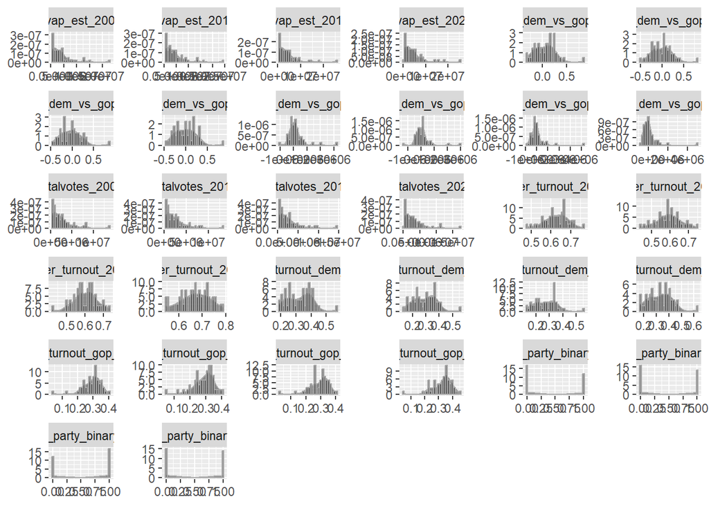

```r
# Histograms
voting_info_final_pivot %>%
  keep(is.numeric) %>%
  gather() %>%
  ggplot(aes(value)) +
    facet_wrap(~ key, scales = "free") +
    geom_density(fill = "#222222", alpha = 0.5, color = "darkgray") +
    geom_histogram(aes(y=..density..), alpha=0.5, fill = "#222222", color="darkgray", position="identity") +
  theme(axis.title = element_blank())
```

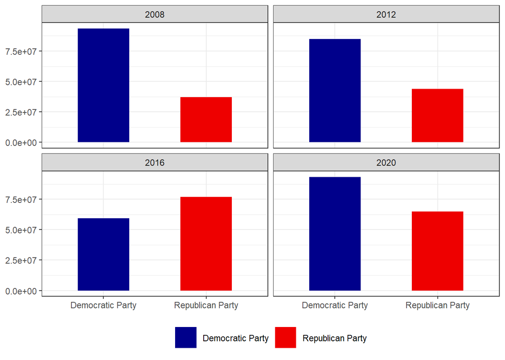

```r
voting_info_final %>%
  group_by(year, winning_party) %>%
  summarise(count = sum(totalvotes)) %>%
  ggplot(aes(x = winning_party, y = count, fill = winning_party)) +  # Map fill to winning_party
  scale_fill_manual(values = c("darkblue","red2"))+
  geom_col(width = 0.5) +  #adjust the width as needed
  facet_wrap(~year) +
  theme_bw() + # Setting background as blank
  theme(legend.position = "bottom",#legend.position = c(0.11, 0.1), #puts legend inside the plot
        # legend.text = element_text(size = 6), #, family = "Arial"
        legend.key.size = unit(8, "mm"), #changes the size of the legend symbol
        legend.title = element_blank(), #removes legend title
        legend.spacing.x = unit(.25, 'cm'),
        axis.title = element_blank()
        )
```

## Detect Multicollinearity Using Correlation Matrix

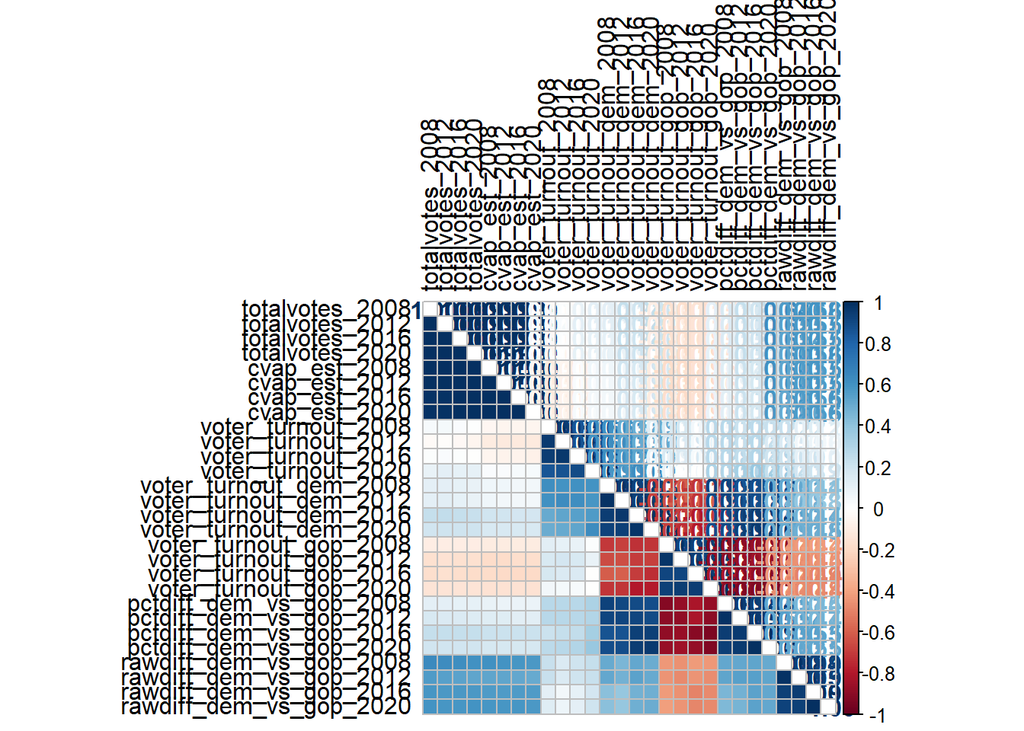

```r
df <- voting_info_final_pivot %>%
  select(-c(state, starts_with("winning"))) %>%
  keep(is.numeric)

cor_matrix <- cor(df)

# Create a heatmap for the correlation matrix
# Visualize correlation between variables
corrplot.mixed(cor(df %>% keep(is.numeric)), tl.col = 'black', tl.pos = 'lt', upper = "number", lower="shade", shade.col=NA, tl.srt=90 )
```

## Detect Multicollinearity Using VIF

The Variance Inflation Factor (VIF) helps quantify how much multicollinearity exists by showing how much the variance of a coefficient is inflated due to linear dependence with other predictors.

VIF Interpretation:  
VIF = 1: No correlation between the predictor and other variables.  
VIF between 1 and 5: Moderate correlation.  
VIF > 5 (or sometimes > 10): High multicollinearity, and you may want to consider removing this variable.

```r
vif_data <- vif(lm(totalvotes_2020 ~ ., data=df))  # Fit a linear model and calculate VIF
print(vif_data)
```

```
##         totalvotes_2008         totalvotes_2012         totalvotes_2016
##              12668.3908              12694.3444               7599.7554
##           cvap_est_2008           cvap_est_2012           cvap_est_2016
##             148251.5428             359757.1275             134479.5925
##           cvap_est_2020      voter_turnout_2008      voter_turnout_2012
##              29345.9999                731.9125                989.6403
##      voter_turnout_2016      voter_turnout_2020  voter_turnout_dem_2008
##                174.6884                823.5184               2021.3224
##  voter_turnout_dem_2012  voter_turnout_dem_2016  voter_turnout_dem_2020
##               2140.8185               1248.5868               4274.2918
##  voter_turnout_gop_2008  voter_turnout_gop_2012  voter_turnout_gop_2016
##               1046.6863               1622.7741               1075.2029
##  voter_turnout_gop_2020 pctdiff_dem_vs_gop_2008 pctdiff_dem_vs_gop_2012
##                926.9023               1768.3352               2541.5297
## pctdiff_dem_vs_gop_2016 pctdiff_dem_vs_gop_2020 rawdiff_dem_vs_gop_2008
##               3328.2442               2357.2987                379.9912
## rawdiff_dem_vs_gop_2012 rawdiff_dem_vs_gop_2016 rawdiff_dem_vs_gop_2020
##                427.1657                998.3352                655.8737
```

```r
# Convert VIF values to a dataframe for visualization
vif_df <- as.data.frame(vif_data)
vif_df$variables <- rownames(vif_df)

# ggplot(vif_df, aes(x=reorder(variables, V1), y=V1)) +
#   geom_bar(stat="identity", fill="steelblue") +
#   coord_flip() +
#   theme_minimal() +
#   labs(title="VIF of Variables", x="Variables", y="VIF")
```

# Build Model

Based on the VIF values shown in our exploratory data analysis, it is evident there is high multicollinearity in our data. Multicollinearity, can cause problems in some models (like linear regression) but may not be as critical for tree-based methods like Random Forests. As such, we will build a Random Forest Model.

## Base model

### Train

```r
#train
df_subset <- voting_info_final_pivot %>%
  select(-c("winning_party_2008", "winning_party_2012", "winning_party_2020", "winning_party_2016")) %>%
  mutate(across(starts_with("winning"), as.factor),
         state = as.factor(state))

# Split the data into training and testing sets (70% train, 30% test)
set.seed(123)  # for reproducibility
train_indices <- sample(seq_len(nrow(df_subset)), size = 0.7 * nrow(df_subset))
train_data <- df_subset[train_indices, ]
test_data <- df_subset[-train_indices, ]

rf_model <- randomForest(winning_party_binary_2020 ~ ., data = train_data, ntree = 500, mtry = 5, importance = TRUE)

# View the model summary
print(rf_model)
```

```
##
## Call:
##  randomForest(formula = winning_party_binary_2020 ~ ., data = train_data,      ntree = 500, mtry = 5, importance = TRUE)
##                Type of random forest: classification
##                      Number of trees: 500
## No. of variables tried at each split: 5
##
##         OOB estimate of  error rate: 2.86%
## Confusion matrix:
##    0  1 class.error
## 0 16  1  0.05882353
## 1  0 18  0.00000000
```

This is the out-of-bag (OOB) error estimate, which is an internal error estimate in random forests. In this case, the OOB error rate is 2.86%, meaning that the model predicts strongly on the training data based on the OOB observations. Overall, the model proves to be highly accurate with almost perfect results and minimal overfitting.

### Evaluate

```r
#evaluate
# Predictions on the test data
predictions <- predict(rf_model, test_data)

table(predictions)
```

```
## predictions
## 0 1
## 8 7
```

```r
# Confusion matrix to evaluate accuracy
conf_matrix <- confusionMatrix(predictions, test_data$winning_party_binary_2020)
print(conf_matrix)
```

```
## Confusion Matrix and Statistics
##
##           Reference
## Prediction 0 1
##          0 8 0
##          1 1 6
##
##                Accuracy : 0.9333
##                  95% CI : (0.6805, 0.9983)
##     No Information Rate : 0.6
##     P-Value [Acc > NIR] : 0.005172
##
##                   Kappa : 0.8649
##
##  Mcnemar's Test P-Value : 1.000000
##
##             Sensitivity : 0.8889
##             Specificity : 1.0000
##          Pos Pred Value : 1.0000
##          Neg Pred Value : 0.8571
##              Prevalence : 0.6000
##          Detection Rate : 0.5333
##    Detection Prevalence : 0.5333
##       Balanced Accuracy : 0.9444
##
##        'Positive' Class : 0
##
```

The test data correctly predicts Democrat Party for the 2020 election.

Accuracy is the proportion of correct predictions over the total number of predictions: Accuracy =8+6/(8+6+1+0) = 0.9333 or 93.33% This indicates the model correctly classified 93.33% of the test data.

### Checking for Overfitting

```r
rf_cv <- train(winning_party_binary_2020 ~ ., data = train_data, method = "rf", trControl = trainControl(method = "cv", number = 10))

print(rf_cv)
```

```
## Random Forest
##
## 35 samples
## 32 predictors
##  2 classes: '0', '1'
##
## No pre-processing
## Resampling: Cross-Validated (10 fold)
## Summary of sample sizes: 32, 31, 31, 32, 32, 31, ...
## Resampling results across tuning parameters:
##
##   mtry  Accuracy   Kappa
##    2    0.9416667  0.89
##   41    0.9750000  0.95
##   80    0.9750000  0.95
##
## Accuracy was used to select the optimal model using the largest value.
## The final value used for the model was mtry = 41.
```

If deployed, the model should generalize well given the robustness of Random Forest and the cross-validation methodology used.

## Demographic data

```r
# To obtain data for the 2008 population from the American Community Survey (ACS),
# you should use the 2006-2008 ACS 3-Year Estimates. This dataset aggregates data
# collected over those three years, providing insights for the population during that period.
# 5 year ACS data unavailable for 2008. 3 year ACS data was discontinued after 2009.

#load 2008 data using API
ed_attain2008 <- get_acs(
  geography = "county",
  variables = c(paste0("B15001_00", seq(01,09),"E"),paste0("B15001_0", seq(10,83),"E")),
  year = 2008,
  survey = "acs3",
  cache_table = TRUE) %>%
  mutate(year=2008)

#2012 data and onward uses the 5 year ACS data
#load 2012 data using API
ed_attain2012 <- get_acs(
  geography = "county",
  variables = c(paste0("B15001_00", seq(01,09),"E"),paste0("B15001_0", seq(10,83),"E")),
  year = 2012,
  survey = "acs5",
  cache_table = TRUE) %>%
  mutate(year=2012)

#load 2016 data using API
ed_attain2016 <- get_acs(
  geography = "county",
  variables = c(paste0("B15001_00", seq(01,09),"E"),paste0("B15001_0", seq(10,83),"E")),
  year = 2016,
  survey = "acs5",
  cache_table = TRUE) %>%
  mutate(year=2016)

#load 2020 data using API
ed_attain2020 <- get_acs(
  geography = "county",
  variables = c(paste0("B15001_00", seq(01,09),"E"),paste0("B15001_0", seq(10,83),"E")),
  year = 2020,
  survey = "acs5",
  cache_table = TRUE) %>%
  mutate(year=2020)
```

#### Get column names

```r
#check column names
#get column names 2008
url08 <- "https://api.census.gov/data/2008/acs/acs3/groups/B15001.html"

webpage08 <- read_html(url08)

table08 <- webpage08 %>%
  html_node("table") %>%  # Adjust the selector if necessary
  html_table() %>%
  select(c("Name","Label","Concept","Required","Attributes","Limit","Predicate Type","Group"))

filteredtable08 <- table08 %>%
  # filter(!is.na(Name) & Name != "") %>%  # Remove rows with NA or empty names
  filter(Name %in% c(paste0("B15001_00", seq(01,09),"E"),paste0("B15001_0", seq(10,83),"E")))
# %>%
#    mutate(Label = str_replace_all(Label,", GED, or alternative", ' (includes equivalency)'))

#get column names  2012
url12 <- "https://api.census.gov/data/2012/acs/acs5/groups/B15001.html"

webpage12 <- read_html(url12)

table12 <- webpage12 %>%
  html_node("table") %>%  # Adjust the selector if necessary
  html_table() %>%
  select(c("Name","Label","Concept","Required","Attributes","Limit","Predicate Type","Group"))

filteredtable12 <- table12 %>%
  # filter(!is.na(Name) & Name != "") %>%  # Remove rows with NA or empty names
  filter(Name %in% c(paste0("B15001_00", seq(01,09),"E"),paste0("B15001_0", seq(10,83),"E")))
# %>%
#    mutate(Label = str_replace_all(Label,", GED, or alternative", ' (includes equivalency)'))

#get column names 2016
url16 <- "https://api.census.gov/data/2016/acs/acs5/groups/B15001.html"

webpage16 <- read_html(url16)

table16 <- webpage16 %>%
  html_node("table") %>%  # Adjust the selector if necessary
  html_table() %>%
  select(c("Name","Label","Concept","Required","Attributes","Limit","Predicate Type","Group"))

filteredtable16 <- table16 %>%
  # filter(!is.na(Name) & Name != "") %>%  # Remove rows with NA or empty names
  filter(Name %in% c(paste0("B15001_00", seq(01,09),"E"),paste0("B15001_0", seq(10,83),"E")))

#get columnn names 2020
url20 <- "https://api.census.gov/data/2020/acs/acs5/groups/B15001.html"

webpage20 <- read_html(url20)

table20 <- webpage20 %>%
  html_node("table") %>%  # Adjust the selector if necessary
  html_table() %>%
  select(c("Name","Label","Concept","Required","Attributes","Limit","Predicate Type","Group"))

filteredtable20 <- table20 %>%
  # filter(!is.na(Name) & Name != "") %>%  # Remove rows with NA or empty names
  filter(Name %in% c(paste0("B15001_00", seq(01,09),"E"),paste0("B15001_0", seq(10,83),"E"))) %>%
  mutate(Label = str_replace_all(Label,":",""))
```

```r
#update the mismatches
filteredtable08 <- filteredtable08 %>%
   mutate(Label = str_replace_all(Label,", GED, or alternative", ' (includes equivalency)'))

filteredtable12 <- filteredtable12 %>%
  mutate(Label = str_replace_all(Label,", GED, or alternative", ' (includes equivalency)'))
```

All column names are the same across all 4 election year Educational Attainment data.

#### Combine and merge education data

```r
ed_attain <- rbind(ed_attain2008, ed_attain2012, ed_attain2016, ed_attain2020)
```

```r
ed_colnames <- filteredtable20 %>%
  mutate(Name = str_replace_all(Name,"E","")) %>%
  select(c(Name, Label))

table(sort(unique(ed_colnames$Name))==sort(unique(ed_attain$variable)))
```

```
##
## TRUE
##   83
```

```r
ed_attain2a <- left_join(ed_attain, ed_colnames, by = c("variable"="Name"))

glimpse(ed_attain2a)
```

```
## Rows: 958,567
## Columns: 7
## $ GEOID    <chr> "01001", "01001", "01001", "01001", "01001", "01001", "01001"…
## $ NAME     <chr> "Autauga County, Alabama", "Autauga County, Alabama", "Autaug…
## $ variable <chr> "B15001_001", "B15001_002", "B15001_003", "B15001_004", "B150…
## $ estimate <dbl> 36493, 17387, 2160, 0, 543, 913, 567, 14, 123, 0, 3157, 64, 3…
## $ moe      <dbl> 132, 127, 182, 154, 260, 286, 177, 24, 89, 154, 244, 76, 222,…
## $ year     <dbl> 2008, 2008, 2008, 2008, 2008, 2008, 2008, 2008, 2008, 2008, 2…
## $ Label    <chr> "Estimate!!Total", "Estimate!!Total!!Male", "Estimate!!Total!…
```

```r
#identify empty and NA values
colSums(ed_attain2a == "" | is.na(ed_attain2a))
```

```
##    GEOID     NAME variable estimate      moe     year    Label
##        0        0        0        0     8584        0        0
```

#### Clean and reshape data

```r
# voteFIPS <- unique(voting_info_final_pivot$FIPS)
demoFIPS <- unique(ed_attain2a$GEOID)

ed_attain2 <- ed_attain2a %>%
  filter(!GEOID %in% setdiff(demoFIPS, FIPS)) %>% #keep only the fips we have in the voting dataset
  separate(col="NAME", into=c("county", "state"), sep=",") %>%
  mutate(county = str_remove(county, " County"),
         county = if_else(county == "Doña Ana", "Dona Ana", county)
         )

ed_attain3 <- ed_attain2 %>%
  group_by(state, year, variable, Label) %>%
  summarise(estimate = sum(estimate),
            moe = sum(moe)) %>%
  mutate(Label2 = Label) %>%
  separate(Label2, into = c("type","value","gender", "age_group", "education"), sep = "!!")
length(unique(ed_attain3$GEOID))
```

```
## [1] 0
```

```r
# edcountystate <- ed_attain3 %>%
#   select(GEOID,county, state) %>%
#   distinct(GEOID,county,state) %>%
#   group_by(GEOID) %>%
#   summarise(count=n())
```

```r
head(ed_attain3, 10)
```

```
## # A tibble: 10 × 11
## # Groups:   state, year, variable [10]
##    state       year variable   Label estimate   moe type  value gender age_group
##    <chr>      <dbl> <chr>      <chr>    <dbl> <dbl> <chr> <chr> <chr>  <chr>
##  1 " Alabama"  2008 B15001_001 Esti…  3312158  3241 Esti… Total <NA>   <NA>
##  2 " Alabama"  2008 B15001_002 Esti…  1575413  4947 Esti… Total Male   <NA>
##  3 " Alabama"  2008 B15001_003 Esti…   216719  7405 Esti… Total Male   18 to 24…
##  4 " Alabama"  2008 B15001_004 Esti…     5635  5162 Esti… Total Male   18 to 24…
##  5 " Alabama"  2008 B15001_005 Esti…    43862 12926 Esti… Total Male   18 to 24…
##  6 " Alabama"  2008 B15001_006 Esti…    74290 15113 Esti… Total Male   18 to 24…
##  7 " Alabama"  2008 B15001_007 Esti…    72890 15034 Esti… Total Male   18 to 24…
##  8 " Alabama"  2008 B15001_008 Esti…     7478  5801 Esti… Total Male   18 to 24…
##  9 " Alabama"  2008 B15001_009 Esti…    11740  6353 Esti… Total Male   18 to 24…
## 10 " Alabama"  2008 B15001_010 Esti…      824  6330 Esti… Total Male   18 to 24…
## # ℹ 1 more variable: education <chr>
```

```r
#identify empty and NA values
colSums(ed_attain3 == "" | is.na(ed_attain3))
```

```
##     state      year  variable     Label  estimate       moe      type     value
##         0         0         0         0         0      1065         0         0
##    gender age_group education
##       200       600      2600
```

```r
ed_attain3_na <- ed_attain3 %>%
  filter(is.na(gender) | is.na(age_group) | is.na(education)) #is.na(gender) |

ed_attain3_na %>%
  count(variable, Label)
```

```
## # A tibble: 2,600 × 5
## # Groups:   state, year, variable [2,600]
##    state       year variable   Label                                        n
##    <chr>      <dbl> <chr>      <chr>                                    <int>
##  1 " Alabama"  2008 B15001_001 Estimate!!Total                              1
##  2 " Alabama"  2008 B15001_002 Estimate!!Total!!Male                        1
##  3 " Alabama"  2008 B15001_003 Estimate!!Total!!Male!!18 to 24 years        1
##  4 " Alabama"  2008 B15001_011 Estimate!!Total!!Male!!25 to 34 years        1
##  5 " Alabama"  2008 B15001_019 Estimate!!Total!!Male!!35 to 44 years        1
##  6 " Alabama"  2008 B15001_027 Estimate!!Total!!Male!!45 to 64 years        1
##  7 " Alabama"  2008 B15001_035 Estimate!!Total!!Male!!65 years and over     1
##  8 " Alabama"  2008 B15001_043 Estimate!!Total!!Female                      1
##  9 " Alabama"  2008 B15001_044 Estimate!!Total!!Female!!18 to 24 years      1
## 10 " Alabama"  2008 B15001_052 Estimate!!Total!!Female!!25 to 34 years      1
## # ℹ 2,590 more rows
```

```r
unique(ed_attain3_na$variable)
```

```
##  [1] "B15001_001" "B15001_002" "B15001_003" "B15001_011" "B15001_019"
##  [6] "B15001_027" "B15001_035" "B15001_043" "B15001_044" "B15001_052"
## [11] "B15001_060" "B15001_068" "B15001_076"
```

```r
#total county population
tot_pop <- ed_attain3 %>%
  filter(is.na(gender)) %>%
  select(state,  estimate, year, value) #value is the column name that will be used to spread/pivot_wider
#male/female county population
gen <- ed_attain3 %>%
  filter(is.na(age_group), !is.na(gender)) %>%
  select(state,  estimate, year, gender)
#gender and age grp population
age_gen_pop <- ed_attain3_na %>%
  filter(!is.na(age_group)) %>%
  select(state,  estimate, year, gender, age_group)
#gender, age, education
ed_pop <- ed_attain3 %>%
  filter(!is.na(education)) %>%
  select(state, estimate, year, gender, age_group, education)
#age, education
age <- ed_pop %>%
  group_by(state,  year, age_group) %>%
  summarise(estimate = sum(estimate))
#gender, education
ed_pop2 <- ed_pop %>%
  group_by(state,  year, gender, education) %>%
  summarise(estimate = sum(estimate))
#age, education
ed_pop3 <- ed_pop %>%
  group_by(state,  year, age_group,  education) %>%
  summarise(estimate = sum(estimate))
#education
ed_pop4 <- ed_pop %>%
  group_by(state,  year, education) %>%
  summarise(estimate = sum(estimate))
```

### Age, Gender, Education

```r
#need to spread/pivot_wider and then merge with main dataset for modelling
#age
age <- ed_pop %>%
  group_by(state,  year, age_group) %>%
  summarise(estimate = sum(estimate))
#gender
gen <- ed_attain3 %>%
  filter(is.na(age_group), !is.na(gender)) %>%
  select(state,  estimate, year, gender)
#education level
edu <- ed_pop %>%
  group_by(state,  year, education) %>%
  summarise(estimate = sum(estimate))
#age pivoted
age2 <- age %>%
  pivot_wider(id_cols = c(state),
              names_from = c(year,age_group),
              values_from = estimate)

colSums(age2 == "" | is.na(age2))
```

```
##                  state    2008_18 to 24 years    2008_25 to 34 years
##                      0                      0                      0
##    2008_35 to 44 years    2008_45 to 64 years 2008_65 years and over
##                      0                      0                      0
##    2012_18 to 24 years    2012_25 to 34 years    2012_35 to 44 years
##                      0                      0                      0
##    2012_45 to 64 years 2012_65 years and over    2016_18 to 24 years
##                      0                      0                      0
##    2016_25 to 34 years    2016_35 to 44 years    2016_45 to 64 years
##                      0                      0                      0
## 2016_65 years and over    2020_18 to 24 years    2020_25 to 34 years
##                      0                      0                      0
##    2020_35 to 44 years    2020_45 to 64 years 2020_65 years and over
##                      0                      0                      0
```

```r
#gender pivoted
gen2 <- gen %>%
  pivot_wider(id_cols = c(state),
              names_from = c(year, gender),
              values_from = estimate)

colSums(gen2 == "" | is.na(gen2))
```

```
##       state   2008_Male 2008_Female   2012_Male 2012_Female   2016_Male
##           0           0           0           0           0           0
## 2016_Female   2020_Male 2020_Female
##           0           0           0
```

```r
#edu pivoted
edu2 <- edu %>%
  pivot_wider(id_cols = c(state),
              names_from = c(year, education),
              values_from = estimate)

colSums(edu2 == "" | is.na(edu2))
```

```
##                                            state
##                                                0
##               2008_9th to 12th grade, no diploma
##                                                0
##                          2008_Associate's degree
##                                                0
##                           2008_Bachelor's degree
##                                                0
##             2008_Graduate or professional degree
##                                                0
## 2008_High school graduate (includes equivalency)
##                                                0
##                         2008_Less than 9th grade
##                                                0
##                     2008_Some college, no degree
##                                                0
##               2012_9th to 12th grade, no diploma
##                                                0
##                          2012_Associate's degree
##                                                0
##                           2012_Bachelor's degree
##                                                0
##             2012_Graduate or professional degree
##                                                0
## 2012_High school graduate (includes equivalency)
##                                                0
##                         2012_Less than 9th grade
##                                                0
##                     2012_Some college, no degree
##                                                0
##               2016_9th to 12th grade, no diploma
##                                                0
##                          2016_Associate's degree
##                                                0
##                           2016_Bachelor's degree
##                                                0
##             2016_Graduate or professional degree
##                                                0
## 2016_High school graduate (includes equivalency)
##                                                0
##                         2016_Less than 9th grade
##                                                0
##                     2016_Some college, no degree
##                                                0
##               2020_9th to 12th grade, no diploma
##                                                0
##                          2020_Associate's degree
##                                                0
##                           2020_Bachelor's degree
##                                                0
##             2020_Graduate or professional degree
##                                                0
## 2020_High school graduate (includes equivalency)
##                                                0
##                         2020_Less than 9th grade
##                                                0
##                     2020_Some college, no degree
##                                                0
```

```r
age2 <- age2 %>%
  select(-starts_with("2008"))

gen2 <- gen2 %>%
  select(-starts_with("2008"))

edu2 <- edu2 %>%
  select(-starts_with("2008"))
```

```r
dem0 <- left_join(age2, gen2, by = c("state"))

dem <- left_join(dem0, edu2, by = c("state")) %>%
  ungroup()

#check dimensions, there is an extra state now
dim(dem)
```

```
## [1] 50 43
```

```r
#na / empty cell check
colSums(dem == "" | is.na(dem))
```

```
##                                            state
##                                                0
##                              2012_18 to 24 years
##                                                0
##                              2012_25 to 34 years
##                                                0
##                              2012_35 to 44 years
##                                                0
##                              2012_45 to 64 years
##                                                0
##                           2012_65 years and over
##                                                0
##                              2016_18 to 24 years
##                                                0
##                              2016_25 to 34 years
##                                                0
##                              2016_35 to 44 years
##                                                0
##                              2016_45 to 64 years
##                                                0
##                           2016_65 years and over
##                                                0
##                              2020_18 to 24 years
##                                                0
##                              2020_25 to 34 years
##                                                0
##                              2020_35 to 44 years
##                                                0
##                              2020_45 to 64 years
##                                                0
##                           2020_65 years and over
##                                                0
##                                        2012_Male
##                                                0
##                                      2012_Female
##                                                0
##                                        2016_Male
##                                                0
##                                      2016_Female
##                                                0
```

[output cut: 31 more lines]

```
##                                                0
##               2020_9th to 12th grade, no diploma
##                                                0
##                          2020_Associate's degree
##                                                0
##                           2020_Bachelor's degree
##                                                0
##             2020_Graduate or professional degree
##                                                0
## 2020_High school graduate (includes equivalency)
##                                                0
##                         2020_Less than 9th grade
##                                                0
##                     2020_Some college, no degree
##                                                0
```

```r
#check for dupe, no dupe, but Puerto Rico needs to be filtered out
unique(dem$state)
```

```
##  [1] " Alabama"              " Arizona"              " Arkansas"
##  [4] " California"           " Colorado"             " Connecticut"
##  [7] " Delaware"             " District of Columbia" " Florida"
## [10] " Georgia"              " Hawaii"               " Idaho"
## [13] " Illinois"             " Indiana"              " Iowa"
## [16] " Kansas"               " Kentucky"             " Louisiana"
## [19] " Maine"                " Maryland"             " Massachusetts"
## [22] " Michigan"             " Minnesota"            " Mississippi"
## [25] " Missouri"             " Montana"              " Nebraska"
## [28] " Nevada"               " New Hampshire"        " New Jersey"
## [31] " New Mexico"           " New York"             " North Carolina"
## [34] " North Dakota"         " Ohio"                 " Oklahoma"
## [37] " Oregon"               " Pennsylvania"         " Rhode Island"
## [40] " South Carolina"       " South Dakota"         " Tennessee"
## [43] " Texas"                " Utah"                 " Vermont"
## [46] " Virginia"             " Washington"           " West Virginia"
## [49] " Wisconsin"            " Wyoming"
```

#### Clean up

```r
dem <- dem %>%
  filter(!str_detect(state, "Puerto Rico")) %>%
  mutate(state = trimws(state, which="both"))

voting_info_final_pivot <- voting_info_final_pivot %>%
  mutate(state = str_to_title(state))
```

### Merge with model data

```r
model_data <- left_join(voting_info_final_pivot, dem, join_by(state == state))

dim(model_data)
```

```
## [1] 50 79
```

```r
colSums(model_data == "" | is.na(model_data))
```

```
##                                            state
##                                                0
##                                  totalvotes_2008
##                                                0
##                                  totalvotes_2012
##                                                0
##                                  totalvotes_2016
##                                                0
##                                  totalvotes_2020
##                                                0
##                                    cvap_est_2008
##                                                0
##                                    cvap_est_2012
##                                                0
##                                    cvap_est_2016
##                                                0
##                                    cvap_est_2020
##                                                0
##                               voter_turnout_2008
##                                                0
##                               voter_turnout_2012
##                                                0
##                               voter_turnout_2016
##                                                0
##                               voter_turnout_2020
##                                                0
##                           voter_turnout_dem_2008
##                                                0
##                           voter_turnout_dem_2012
##                                                0
##                           voter_turnout_dem_2016
##                                                0
##                           voter_turnout_dem_2020
##                                                0
##                           voter_turnout_gop_2008
##                                                0
##                           voter_turnout_gop_2012
##                                                0
##                           voter_turnout_gop_2016
##                                                0
```

[output cut: 103 more lines]

```
##                                                1
##               2020_9th to 12th grade, no diploma
##                                                1
##                          2020_Associate's degree
##                                                1
##                           2020_Bachelor's degree
##                                                1
##             2020_Graduate or professional degree
##                                                1
## 2020_High school graduate (includes equivalency)
##                                                1
##                         2020_Less than 9th grade
##                                                1
##                     2020_Some college, no degree
##                                                1
```

```r
model_data2 <- model_data %>%
  drop_na() %>%
  janitor::clean_names()

dim(model_data2)
```

```
## [1] 49 79
```

```r
#train
df_subset2 <- model_data2 %>%
  select(-c("winning_party_2008", "winning_party_2012", "winning_party_2020", "winning_party_2016")) %>%
  mutate(across(starts_with("winning"), as.factor),
         state = as.factor(state))

# Split the data into training and testing sets (70% train, 30% test)
set.seed(123)  # for reproducibility
train_indices2 <- sample(seq_len(nrow(df_subset2)), size = 0.7 * nrow(df_subset2))
train_data2 <- df_subset2[train_indices2, ]
test_data2 <- df_subset2[-train_indices2, ]

rf_model2 <- randomForest(winning_party_binary_2020 ~ ., data = train_data2, ntree = 500, mtry = 5, importance = TRUE)

# View the model summary
print(rf_model2)
```

```
##
## Call:
##  randomForest(formula = winning_party_binary_2020 ~ ., data = train_data2,      ntree = 500, mtry = 5, importance = TRUE)
##                Type of random forest: classification
##                      Number of trees: 500
## No. of variables tried at each split: 5
##
##         OOB estimate of  error rate: 5.88%
## Confusion matrix:
##    0  1 class.error
## 0 15  1  0.06250000
## 1  1 17  0.05555556
```

True 0 (15): 15 instances of class 0 were correctly classified.

False 0 (1): 1 instance was incorrectly classified as 0.

True 1 (17): 17 instances of class 1 were correctly classified.

False 1 (1): Only 1 instance was incorrectly classified as 1.

### Evaluate

```r
#evaluate
# Predictions on the test data
predictions2 <- predict(rf_model2, test_data2)

#0= dem, 1=rep
table(predictions2)
```

```
## predictions2
## 0 1
## 8 7
```

```r
# Confusion matrix to evaluate accuracy
conf_matrix2 <- confusionMatrix(predictions2, test_data2$winning_party_binary_2020)
print(conf_matrix2)
```

```
## Confusion Matrix and Statistics
##
##           Reference
## Prediction 0 1
##          0 8 0
##          1 1 6
##
##                Accuracy : 0.9333
##                  95% CI : (0.6805, 0.9983)
##     No Information Rate : 0.6
##     P-Value [Acc > NIR] : 0.005172
##
##                   Kappa : 0.8649
##
##  Mcnemar's Test P-Value : 1.000000
##
##             Sensitivity : 0.8889
##             Specificity : 1.0000
##          Pos Pred Value : 1.0000
##          Neg Pred Value : 0.8571
##              Prevalence : 0.6000
##          Detection Rate : 0.5333
##    Detection Prevalence : 0.5333
##       Balanced Accuracy : 0.9444
##
##        'Positive' Class : 0
##
```

### Checking for Overfitting

```r
rf_cv2 <- train(winning_party_binary_2020 ~ ., data = train_data2, method = "rf", trControl = trainControl(method = "cv", number = 10))

print(rf_cv2)
```

```
## Random Forest
##
## 34 samples
## 74 predictors
##  2 classes: '0', '1'
##
## No pre-processing
## Resampling: Cross-Validated (10 fold)
## Summary of sample sizes: 30, 30, 30, 31, 31, 31, ...
## Resampling results across tuning parameters:
##
##   mtry  Accuracy   Kappa
##     2   0.8500000  0.68
##    61   0.9333333  0.88
##   121   0.9333333  0.88
##
## Accuracy was used to select the optimal model using the largest value.
## The final value used for the model was mtry = 61.
```

# Prediction

```r
predictions_2024 <- predict(rf_model2, df_subset2)

# predictions_2024$predicted_class <-  predictions_2024

#demo = 0, rep = 1
table(predictions_2024) # Republican Party
```

```
## predictions_2024
##  0  1
## 24 25
```

```r
table(df_subset2$winning_party_binary_2020) #Democratic Party
```

```
##
##  0  1
## 25 24
```

```r
table(df_subset2$winning_party_binary_2016) #Republican Party
```

```
##
##  0  1
## 20 29
```